# Child Mortality and Life Expectancy in 2020

This report compares two global health indicators in **2020**:

- **Child mortality** — deaths of children under age 5 per 1,000 live births
- **Life expectancy at birth** — average expected lifespan at birth (years)

## Data for 2020

After subsetting each indicator to 2020, there are 194 countries with child mortality estimates and 194 with life expectancy estimates. The scatter plot below uses the 194 countries with both values available.

Sample of child mortality data (2020)

| Country | Child mortality (per 1,000) |
| --- | --- |
| Afghanistan | 59.08 |
| Angola | 71.44 |
| Albania | 9.75 |
| Andorra | 2.66 |
| UAE | 6.58 |

Sample of life expectancy data (2020)

| Country | Life expectancy (years) |
| --- | --- |
| Afghanistan | 64.6 |
| Angola | 62.8 |
| Albania | 77.4 |
| Andorra | 82.7 |
| UAE | 79.5 |

## World maps (2020)

### Child mortality

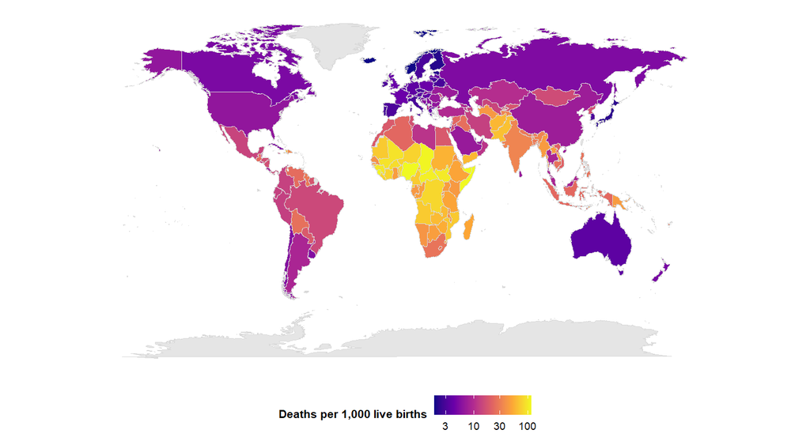

**Figure 1. Child mortality among children under age 5, by country (2020)**

### Life expectancy at birth

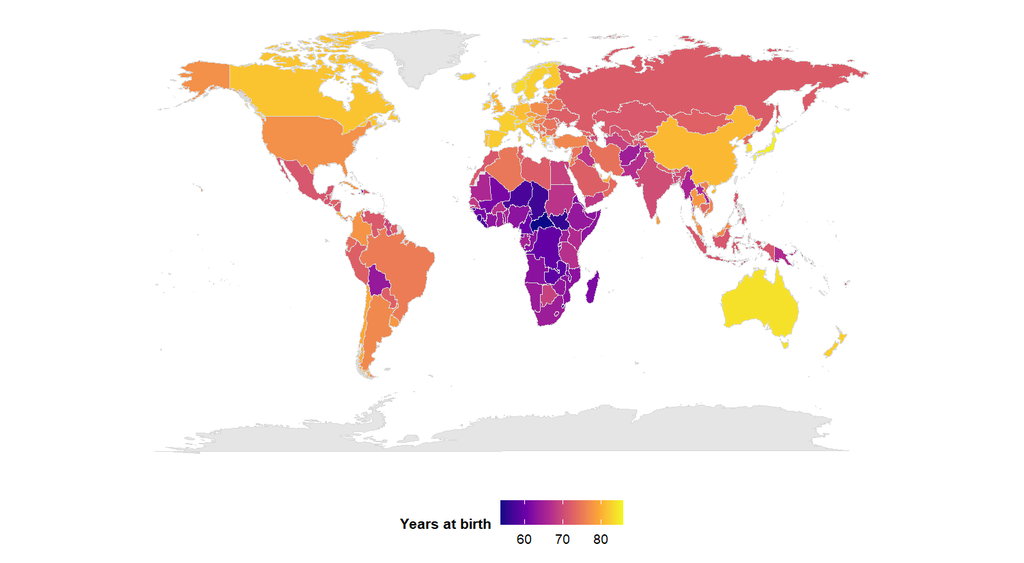

**Figure 2. Life expectancy at birth, by country (2020)**

## Relationship between indicators

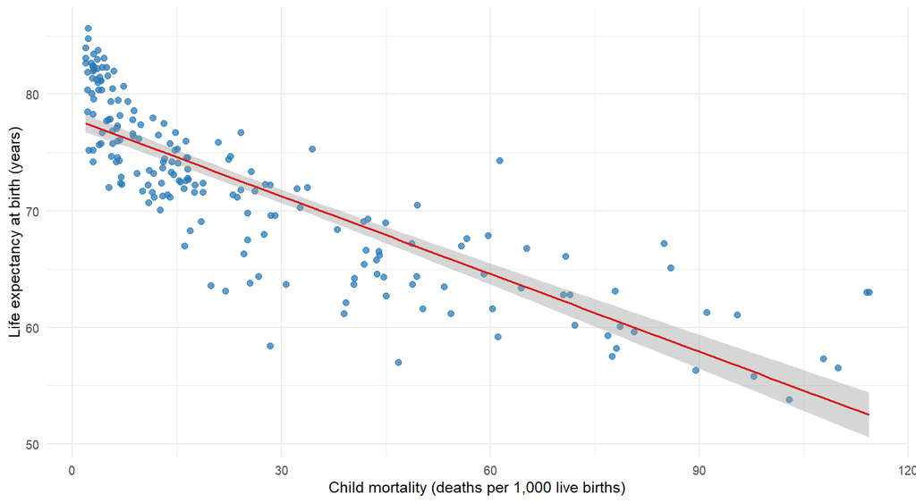

**Figure 3. Relationship between child mortality and life expectancy (2020)**

*Legend:* Each blue point is one country. The red line shows the linear trend; the shaded band is the 95% confidence interval. Countries in the upper-left have lower mortality and longer lives; those in the lower-right have higher mortality and shorter lives.

The Pearson correlation in 2020 is **-0.833** (194 countries).

## Interpretation

Countries with **high child mortality** tend to have **lower life expectancy**. In 2020, the correlation is strongly negative (r = -0.833): early-life survival is a major component of overall longevity, and nations facing poverty, weak health systems, or conflict often score poorly on both measures.

The maps show the same geographic pattern from two angles. Sub-Saharan Africa and parts of South Asia stand out with higher child mortality and shorter lives, while Europe, East Asia, and Oceania cluster at the low-mortality, high-longevity end. The scatterplot tightens this pattern: most observations fall along a descending line, so improvements in child survival are systematically associated with longer average lifespans, though individual countries can diverge from the trend because of adult mortality, demographics, and data uncertainty.

## My reflections on Cursor tool

The easiest part for me was getting quick explanations or suggestions that would have taken me much longer to figure out on my own. The most challenging part, however, was learning how to phrase my prompts clearly enough to get the results I actually needed. I realized that the quality of the output depends heavily on the precision of the input. I was also surprised by how confident the AI can sound even when its answers require verification. But it has also an automated-regulation and auto-correction, which is efficient as feedback loop.